# 의학통계방법론 1조 9주차 과제

김재혁, 정지현

2022-05-05

```r
getwd()
```

```
## [1] "C:/git_blog/study/data/의학통계방법론/ch15"
```

```r
library("foreign")
library("dplyr")
library("kableExtra")
```

## 0.1 15장

**15장 연습문제 불러오기**

```r
ex15_1a <- read.spss('Exam 15_1a.sav', to.data.frame=T)
```

## 0.2 EXAMPLE 15.1a

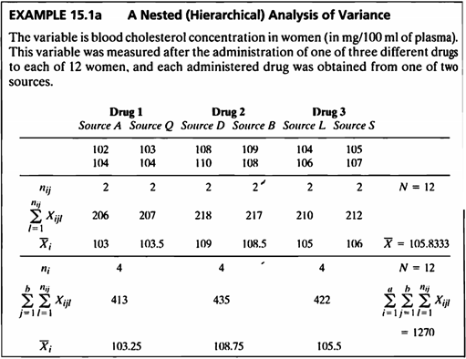

```r
#데이터셋
ex15_1a%>%
  kbl(caption = "Dataset",escape=F) %>%
  kable_styling(bootstrap_options = c("striped", "hover", "condensed", "responsive"))
```

Dataset

| drug | source | subj | resp |
| --- | --- | --- | --- |
| 1 | 1 | 1 | 102 |
| 1 | 1 | 2 | 104 |
| 1 | 2 | 3 | 103 |
| 1 | 2 | 4 | 104 |
| 2 | 3 | 5 | 108 |
| 2 | 3 | 6 | 110 |
| 2 | 4 | 7 | 109 |
| 2 | 4 | 8 | 108 |
| 3 | 5 | 9 | 104 |
| 3 | 5 | 10 | 106 |
| 3 | 6 | 11 | 105 |
| 3 | 6 | 12 | 107 |

- 해당 데이터는 세 가지 약 중 한 가지를 12명의 여성 각각에게 투여한 후 측정된 혈중 콜레스테롤 농도에 대한 데이터이다.

```r
drug <- as.factor(ex15_1a$drug)
source <- as.factor(ex15_1a$source)
```

- 분석을 위해 drug와 source를 factor로 변환해 주었다.

```r
tapply(ex15_1a$resp,drug,sum)
```

```
##   1   2   3
## 413 435 422
```

```r
tapply(ex15_1a$resp,drug,mean)
```

```
##      1      2      3
## 103.25 108.75 105.50
```

## 0.3 EXAMPLE 15.1b

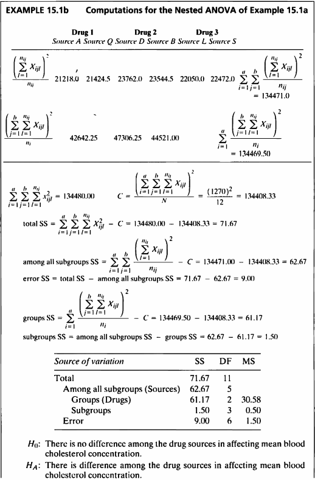

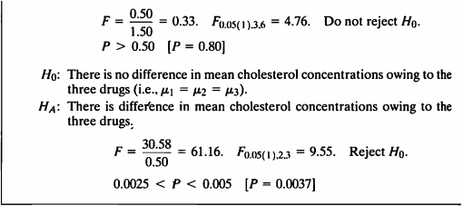

- 콜레스테롤 수치는 drug type과 drug source에 영향을 받으므로, 두 인자를 고려하여 nested ANOVA를 수행하였다.  
  따라서 가설은 아래와 같이 두 가지다.

> 첫번째 가설

$$\begin{aligned}
H_0 &: There \ is \ no \ difference \ among \ the \ drug \ sources \
in \ affecting \ mean \ blood \ cholesterol \ concentration. \\
H_1 &: There \ is \ difference \ among \ the \ drug \ sources \ in \
affecting \ mean \ blood \ cholesterol \ concentration.
\end{aligned}$$

> 두번째 가설

$$\begin{aligned}
H_0 &: There \ is \ no \ difference \ in \ mean \ cholesterol \
concentrations \ owing \ to \ the \ three \ drugs. \\
H_1 &: There \ is \ difference \ in \ mean \ cholesterol \
concentrations \ owing \ to \ the \ three \ drugs.
\end{aligned}$$

```r
fit <- lm(ex15_1a$resp~drug/source)
anova(fit)
```

```
## Analysis of Variance Table
##
## Response: ex15_1a$resp
##             Df Sum Sq Mean Sq F value  Pr(>F)
## drug         2 61.167  30.583 20.3889 0.00211 **
## drug:source  3  1.500   0.500  0.3333 0.80220
## Residuals    6  9.000   1.500
## ---
## Signif. codes:  0 '***' 0.001 '**' 0.01 '*' 0.05 '.' 0.1 ' ' 1
```

```r
fit2 <- aov(ex15_1a$resp~drug+Error(source))
summary(fit2)
```

```
##
## Error: source
##           Df Sum Sq Mean Sq F value Pr(>F)
## drug       2  61.17   30.58   61.17 0.0037 **
## Residuals  3   1.50    0.50
## ---
## Signif. codes:  0 '***' 0.001 '**' 0.01 '*' 0.05 '.' 0.1 ' ' 1
##
## Error: Within
##           Df Sum Sq Mean Sq F value Pr(>F)
## Residuals  6      9     1.5
```

- 두 번째 귀무가설에 대해, p-value=0.0037로 유의수준 5%하에 귀무가설을 기각한다.
- 즉, 세가지 약으로 인한 콜레스테롤 수치 평균은 유의한 차이가 있다고 할 수 있는 근거가 충분하다.

## 0.4 EXAMPLE 15.2

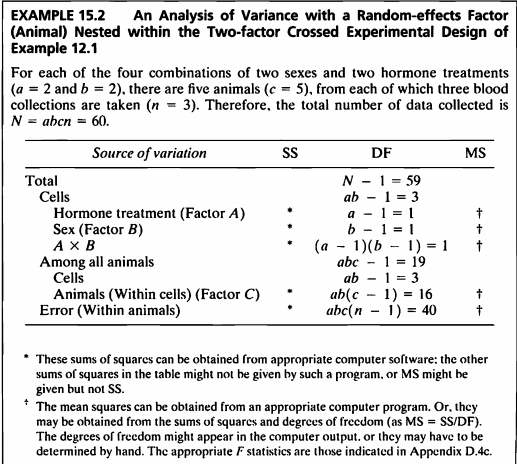

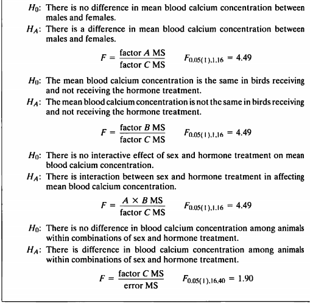

```r
trt<-c(rep('NO',10), rep('YES',10))
gender<-c(rep('female',5),rep('male',5),rep('female',5), rep('male',5))
xx<-c(16.3,20.4,12.4,15.8,9.5,15.3,17.4,10.9,10.3,6.7, 38.1,26.2,32.3,35.8,30.2,34.0,22.8,27.8,25.0,29.3)
trt<-as.factor(trt) ; gender<-as.factor(gender)
ex1502=data.frame(trt,gender,xx)
a=ex1502[1:5,]; aa=a$xx; h0ft1=rnorm(5,mean(aa),1) ; h0ft2=rnorm(5,mean(aa),1)
b=ex1502[6:10,]; bb=b$xx; h0mt1=rnorm(5,mean(bb),1) ; h0mt2=rnorm(5,mean(bb),1)
c=ex1502[11:15,]; cc=c$xx; hxft1=rnorm(5,mean(cc),1) ; hxft2=rnorm(5,mean(cc),1)
d=ex1502[16:20,]; dd=d$xx; hxmt1=rnorm(5,mean(dd),1) ; hxmt2=rnorm(5,mean(dd),1)
new_xx<-c(aa,h0ft1,h0ft2,bb,h0mt1,h0mt2,cc,hxft1,hxft2,dd,hxmt1,hxmt2)
animal<-c(rep(c(1,2,3,4,5),12))
cell<-c(rep(1,15),rep(2,15),rep(3,15),rep(4,15))
new_trt<-c(rep('NO',30), rep('YES',30))
new_gender<-c(rep('female',15),rep('male',15),rep('female',15), rep('male',15))
ex1502a<-data.frame(new_trt,new_gender,cell,animal,new_xx)
new_gender<-as.factor(new_gender) ; new_trt<-as.factor(new_trt) ; cell<-as.factor(cell); animal <- as.factor(animal)
fit_animal<-lm(new_xx ~(new_gender*new_trt)/animal+(new_gender*new_trt)/cell)
anova(fit_animal)
```

```
## Analysis of Variance Table
##
## Response: new_xx
##                           Df Sum Sq Mean Sq  F value    Pr(>F)
## new_gender                 1  218.2   218.2  41.9814 1.002e-07 ***
## new_trt                    1 4194.0  4194.0 806.7965 < 2.2e-16 ***
## new_gender:new_trt         1   18.1    18.1   3.4902   0.06907 .
## new_gender:new_trt:animal 16  111.0     6.9   1.3346   0.22463
## Residuals                 40  207.9     5.2
## ---
## Signif. codes:  0 '***' 0.001 '**' 0.01 '*' 0.05 '.' 0.1 ' ' 1
```